[figure not shown]

# Données pondérées

Ce chapitre est évoqué dans le webin-R #10 (Données pondérées, plan d’échantillonnage complexe & survey) sur [YouTube](https://youtu.be/aXCn9SyhcTE).

S’il est tout à fait possible de travailler avec des données pondérées sous R, cette fonctionnalité n’est pas aussi bien intégrée que dans la plupart des autres logiciels de traitement statistique. En particulier, il y a plusieurs manières possibles de gérer la pondération. Cependant, lorsque l’on doit également prendre un compte un plan d’échantillonnage complexe (voir section dédiée ci-après), **R** fournit tous les outils nécessaires, alors que dans la plupart des logiciels propriétaires, il faut disposer d’une extension adéquate, pas toujours vendue de base avec le logiciel.

Dans ce qui suit, on utilisera le jeu de données tiré de l’enquête *Histoire de vie* et notamment sa variable de pondération *poids*[^1].

```r
library(questionr)
data(hdv2003)
d <- hdv2003
range(d$poids)
```

```
[1]    78.07834 31092.14132
```

## Options de certaines fonctions

Tout d’abord, certaines fonctions de **R** acceptent en argument un vecteur permettant de pondérer les observations (l’option est en général nommée `weights` ou `row.w`). C’est le cas par exemple des méthodes d’estimation de modèles linéaires[^2] (`lm`) ou de modèles linéaires généralisés [^3] (`glm`) ou dans les analyses de correspondances[^4] des extensions `ade4` ou `FactoMineR`.

Par contre cette option n’est pas présente dans les fonctions de base comme `mean`, `var`, `table` ou `chisq.test`.

## Données pondérées avec l’extension survey

L’extension `survey` est spécialement dédiée au traitement d’enquêtes ayant des techniques d’échantillonnage et de pondération potentiellement très complexes.

L’extension s’installe comme la plupart des autres :

```r
install.packages("survey")
```

Le site officiel (en anglais) comporte beaucoup d’informations, mais pas forcément très accessibles :  
http://r-survey.r-forge.r-project.org/.

Pour utiliser les fonctionnalités de l’extension, on doit d’abord définir le plan d’échantillonnage ou design de notre enquête, c’est-à-dire indiquer quel type de pondération nous souhaitons lui appliquer.

Dans un premier temps, nous utiliserons le plan d’échantillonnage le plus simple, avec une variable de pondération déjà calculée. Pour d’autres types de plan d’échantillonnage, voir la chapitre sur les plans d’échantillonnage complexes.

Ceci se fait à l’aide de la fonction `svydesign` :

```r
library(survey)
dw <- svydesign(ids = ~1, data = d, weights = ~ d$poids)
```

Cette fonction crée un nouvel objet, que nous avons nommé `dw`. Cet objet n’est pas à proprement parler un tableau de données, mais plutôt un tableau de données plus une méthode de pondération. `dw` et `d` sont des objets distincts, les opérations effectuées sur l’un n’ont pas d’influence sur l’autre. On peut cependant retrouver le contenu de `d` depuis `dw` en utilisant `dw$variables` :

```r
str(d$age)
```

```
 int [1:2000] 28 23 59 34 71 35 60 47 20 28 ...
```

```r
str(dw$variables$age)
```

```
 int [1:2000] 28 23 59 34 71 35 60 47 20 28 ...
```

Lorsque notre plan d’échantillonnage est déclaré, on peut lui appliquer une série de fonctions permettant d’effectuer diverses opérations statistiques en tenant compte de la pondération. On citera notamment :

- `svymean`, `svyvar`, `svytotal`, `svyquantile` : statistiques univariées (moyenne, variance, total, quantiles)
- `svytable` : tri à plat et tableau croisé
- `svychisq` : test du χ²
- `svyby` : statistiques selon un facteur
- `svyttest` : test t de Student de comparaison de moyennes
- `svyciprop` : intervalle de confiance d’une proportion
- `svyglm` : modèles linéaires généralisés (dont régression logistique)
- `svyplot`, `svyhist`, `svyboxplot` : fonctions graphiques

D’autres fonctions sont disponibles, comme `svyratio`, mais elles ne seront pas abordées ici.

Pour ne rien arranger, ces fonctions prennent leurs arguments sous forme de formules[^5], c’est-à-dire pas de la manière habituelle. En général l’appel de fonction se fait en spécifiant d’abord les variables d’intérêt sous forme de formule, puis l’objet *survey.design*.

Voyons tout de suite quelques exemples[^6] :

```r
svymean(~age, dw)
```

```
      mean     SE
age 46.347 0.5284
```

```r
svyquantile(~age, dw, quantile = c(0.25, 0.5, 0.75), ci = TRUE)
```

```
$age
     quantile ci.2.5 ci.97.5        se
0.25       31     31      33 0.5099045
0.5        45     44      47 0.7648568
0.75       60     59      63 1.0198091

attr(,"hasci")
[1] TRUE
attr(,"class")
[1] "newsvyquantile"
```

```r
svyvar(~heures.tv, dw, na.rm = TRUE)
```

```
          variance     SE
heures.tv   2.9886 0.1836
```

Les tris à plat se déclarent en passant comme argument le nom de la variable précédé d’un tilde (`~`), tandis que les tableaux croisés utilisent les noms des deux variables séparés par un signe plus (`+`) et précédés par un tilde (`~`).

```r
svytable(~sexe, dw)
```

```
sexe
  Homme   Femme
5149382 5921844
```

```r
svytable(~ sexe + clso, dw)
```

```
       clso
sexe           Oui        Non Ne sait pas
  Homme 2658744.04 2418187.64    72450.75
  Femme 2602031.76 3242389.36    77422.79
```

La fonction `freq` peut être utilisée si on lui passe en argument non pas la variable elle-même, mais son tri à plat obtenu avec `svytable` :

```r
tab <- svytable(~peche.chasse, dw)
freq(tab, total = TRUE)
```

|  | n | % | val% |
| --- | --- | --- | --- |
| Non | 9716683 | 87.8 | 87.8 |
| Oui | 1354544 | 12.2 | 12.2 |
| Total | 11071226 | 100.0 | 100.0 |

On peut également récupérer le tableau issu de `svytable` dans un objet et le réutiliser ensuite comme n’importe quel tableau croisé :

```r
tab <- svytable(~ sexe + clso, dw)
tab
```

```
       clso
sexe           Oui        Non Ne sait pas
  Homme 2658744.04 2418187.64    72450.75
  Femme 2602031.76 3242389.36    77422.79
```

Les fonctions `lprop` et `cprop` de `questionr` sont donc tout à fait compatibles avec l’utilisation de `survey`.

```r
lprop(tab)
```

```
          clso
sexe       Oui   Non   Ne sait pas Total
  Homme     51.6  47.0   1.4       100.0
  Femme     43.9  54.8   1.3       100.0
  Ensemble  47.5  51.1   1.4       100.0
```

Le principe de la fonction `svyby` est similaire à celui de `tapply`[^7]. Elle permet de calculer des statistiques selon plusieurs sous-groupes définis par un facteur. Par exemple :

```r
svyby(~age, ~sexe, dw, svymean)
```

|  | sexe | age | se |
| --- | --- | --- | --- |
| Homme | Homme | 45.20200 | 0.7419450 |
| Femme | Femme | 47.34313 | 0.7420836 |

### gtsummary et survey

L’extension `gtsummary` fournit une fonction `tbl_svysummary`, similaire à `tbl_summary`, mais adaptée aux objets `survey`.

```r
library(gtsummary)
theme_gtsummary_language("fr", decimal.mark = ",", big.mark = " ")
```

```
Setting theme `language: fr`
```

```r
dw %>% tbl_svysummary(include = c("age", "sexe", "clso", "peche.chasse"))
```

| **Caractéristique** | **N = 11 071 226**<sup>1</sup> |
| --- | --- |
| age | 45 (31 – 60) |
| sexe |  |
| Homme | 5 149 382 (47%) |
| Femme | 5 921 844 (53%) |
| clso |  |
| Oui | 5 260 776 (48%) |
| Non | 5 660 577 (51%) |
| Ne sait pas | 149 874 (1,4%) |
| peche.chasse |  |
| Non | 9 716 683 (88%) |
| Oui | 1 354 544 (12%) |

<sup>1</sup> Médiane (EI); n (%)

```r
dw %>%
  tbl_svysummary(
    include = c("age", "sexe", "clso", "peche.chasse"),
    by = "sexe"
  ) %>%
  add_overall(last = TRUE) %>%
  add_p()
```

| **Caractéristique** | **Homme**, N = 5 149 382<sup>1</sup> | **Femme**, N = 5 921 844<sup>1</sup> | **Total**, N = 11 071 226<sup>1</sup> | **p-valeur**<sup>2</sup> |
| --- | --- | --- | --- | --- |
| age | 44 (30 – 59) | 45 (32 – 61) | 45 (31 – 60) | 0,067 |
| clso |  |  |  | 0,036 |
| Oui | 2 658 744 (52%) | 2 602 032 (44%) | 5 260 776 (48%) |  |
| Non | 2 418 188 (47%) | 3 242 389 (55%) | 5 660 577 (51%) |  |
| Ne sait pas | 72 451 (1,4%) | 77 423 (1,3%) | 149 874 (1,4%) |  |
| peche.chasse |  |  |  | <0,001 |
| Non | 4 101 242 (80%) | 5 615 441 (95%) | 9 716 683 (88%) |  |
| Oui | 1 048 141 (20%) | 306 403 (5,2%) | 1 354 544 (12%) |  |

<sup>1</sup> Médiane (EI); n (%)  
<sup>2</sup> test de Wilcoxon sur la somme des rangs adapté aux plans d'échantillonnage complexes; test du Chi² avec la correction du second ordre de Rao & Scott

### Graphiques natifs avec survey

`survey` est également capable de produire des graphiques à partir des données pondérées. Quelques exemples :

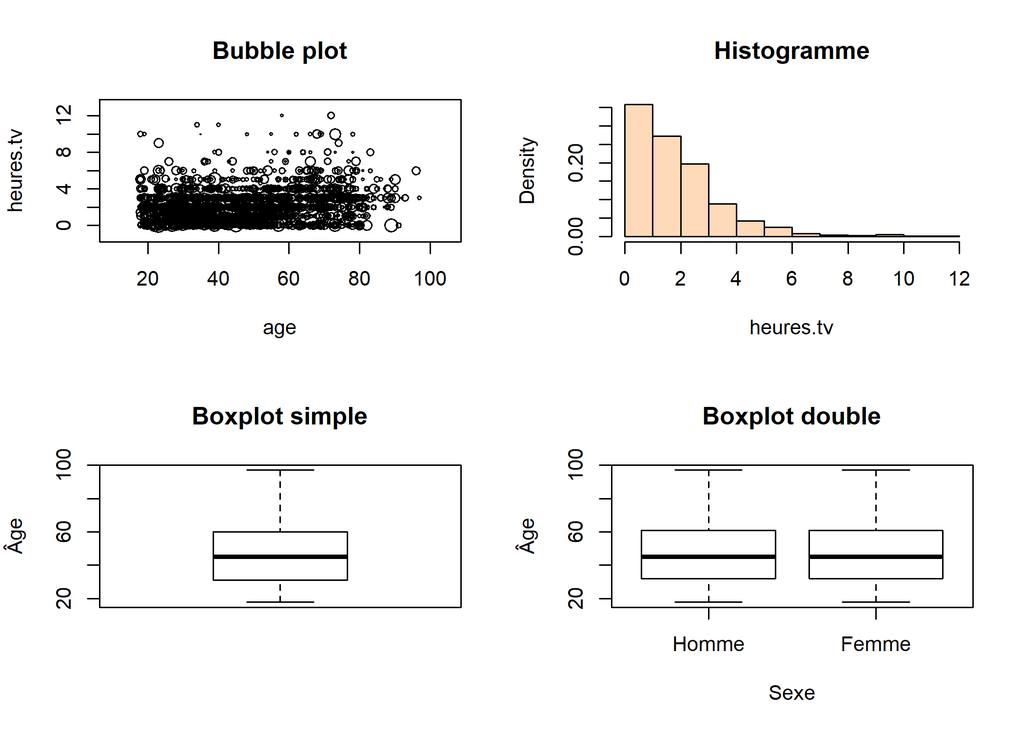

Fonctions graphiques de l’extension survey

```r
par(mfrow = c(2, 2))
svyplot(~ age + heures.tv, dw, col = "red", main = "Bubble plot")
svyhist(~heures.tv, dw, col = "peachpuff", main = "Histogramme")
svyboxplot(age ~ 1, dw, main = "Boxplot simple", ylab = "Âge")
svyboxplot(age ~ sexe, dw, main = "Boxplot double", ylab = "Âge", xlab = "Sexe")
```

### Graphiques ggplot2

`ggplot2` accepte une esthétique `weight` pour indiquer des poids à prendre en compte dans les différents graphiques. La fonction `weights` permets justement de récupérer les poids d’un objet `survey`. La fonction `ggplot` n’accepte pas d’objet `survey` mais a besoin d’un tableau de données. Ce dernier peut être récupéré avec `$variables`.

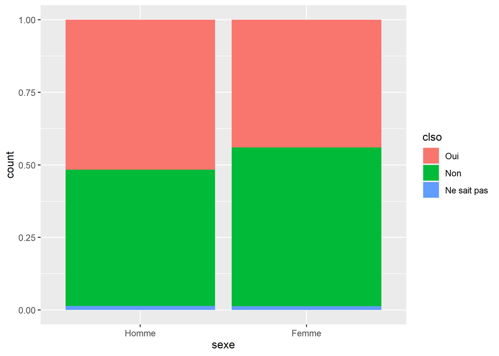

```r
library(ggplot2)
ggplot(dw$variables) +
  aes(weight = weights(dw), x = sexe, fill = clso) +
  geom_bar(position = "fill")
```

**ATTENTION :** les graphiques obtenus ne sont corrects qu’à la condition que seuls les poids soient nécessaires pour les construire, ce qui est le cas d’un nuage de points ou d’un diagramme en barres. Par contre, si le calcul du graphique implique le calcul de variance, la représentation sera incorrecte. Par exemple, avec `geom_smooth`, les aires de confiance affichées ne prendront pas correctement en compte le plan d’échantillonnage.

L’extenstion `questionr` propose, dans sa version de développement, une fonction `ggsurvey` pour faciliter les choses. Elle prend un objet `survey`, extrait le tableau de données et les poids, associe les poids à l’esthétique correspondante et appelle `ggplot`.

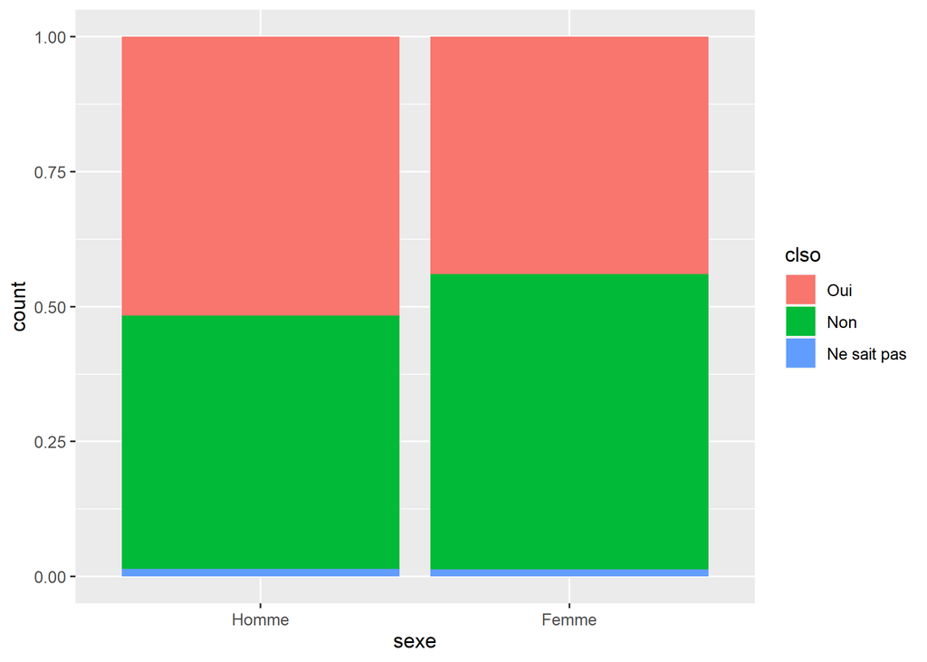

```r
library(questionr)
ggsurvey(dw) +
  aes(x = sexe, fill = clso) +
  geom_bar(position = "fill")
```

Pour installer la version de développement de `questionr`, on pourra utiliser la commande suivante :

```r
if (!require(devtools)) {
  install.packages("devtools")
  library(devtools)
}
install_github("juba/questionr")
```

### Extraire un sous-échantillon

Si l’on souhaite travailler sur un sous-échantillon tout en gardant les informations d’échantillonnage, on utilisera la fonction `subset` présentée en détail dans le chapitre Sous-ensembles.

```r
sous <- subset(dw, sexe == "Femme" & age >= 40)
```

### Modèles logistiques

Pour réaliser des modèles logistiques (binaires, multinomiaux ou ordinaux) avec prise en compte d’un plan d’échantillonnage, on pourra se référer à la sous-section dédiée du chapitre Régression logistique.

### dplyr et survey

L’extension `srvyr` vise à permettre d’utiliser les verbes de `dplyr` avec `survey`. Le fonctionnement de cette extension est expliqué dans une vignette dédiée : https://cran.r-project.org/web/packages/srvyr/vignettes/srvyr-vs-survey.html.

## Conclusion

Si, la gestion de la pondération sous **R** n’est sans doute pas ce qui se fait de plus pratique et de plus simple, on pourra quand même donner les conseils suivants :

- utiliser les options de pondération des fonctions usuelles ou les fonctions d’extensions comme `questionr` pour les cas les plus simples ;
- si on utilise `survey`, effectuer autant que possible tous les recodages et manipulations sur les données non pondérées ;
- une fois les recodages effectués, on déclare le design et on fait les analyses en tenant compte de la pondération ;
- surtout ne jamais modifier les variables du design. Toujours effectuer recodages et manipulations sur les données non pondérées, puis redéclarer le design pour que les mises à jour effectuées soient disponibles pour l’analyse.
[^1]: On notera que cette variable est utilisée à titre purement illustratif. Le jeu de données étant un extrait d’enquête et la variable de pondération n’ayant pas été recalculée, elle n’a ici à proprement parler aucun sens.
[^2]: Voir le chapitre régression linéaire.
[^3]: Voir le chapitre sur la régression logistique.
[^4]: Voir le chapitre dédié à l’analyse des correspondances.
[^5]: Pour plus de détails sur les formules, voir le chapitre dédié.
[^6]: Pour d’autres exemples, voir http://www.ats.ucla.edu/stat/r/faq/svy_r_oscluster.htm (en anglais).
[^7]: La fonction `tapply` est présentée plus en détails dans le chapitre Manipulation de données.